# (Ford GoBike Analysis)

## by (Abdelrahman Fouad)

## Investigation Overview

> This presentation aims to provide insights on the influence of certain factors on the trip durations collected by Ford GoBike in February 2019.

## Dataset Overview

> The data includes data about the trips duratoin of rides and the factors that influenced it.

## Trip Duration for bike rides

The data is right skewed so I had to make some transformations to make it more suitable as a visual.

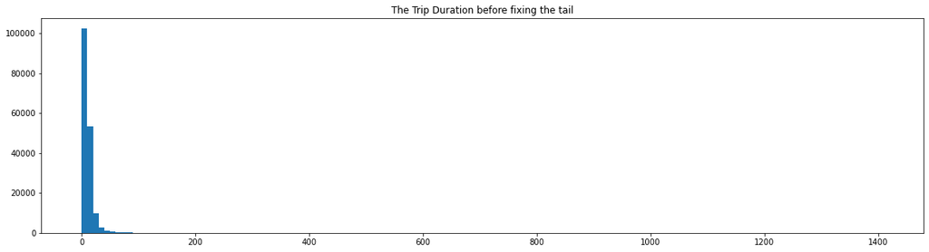

```python
binsize = 10
bins = np.arange(0, df['duration_min'].max()+binsize, binsize)

plt.figure(figsize=[20, 5])
plt.title('The Trip Duration before fixing the tail')
plt.hist(data = df, x = 'duration_min', bins=bins);
```

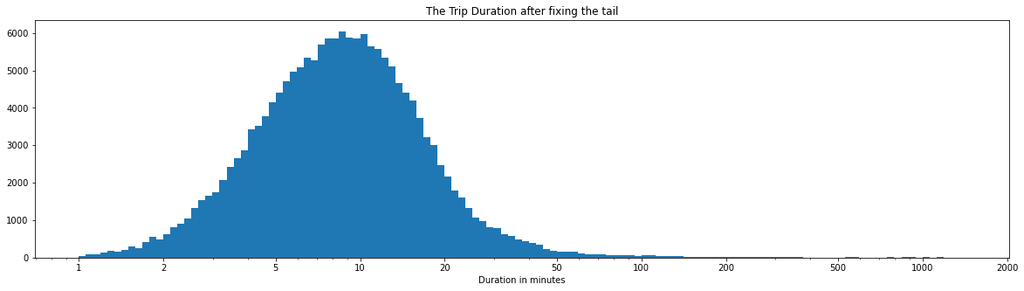

```python
log_binsize = 0.025
bins = 10 ** np.arange(0, np.log10(df['duration_min'].max())+log_binsize, log_binsize)

plt.figure(figsize=[20, 5]);
plt.hist(data = df, x = 'duration_min', bins = bins);
plt.xscale('log');
plt.xticks([1, 2, 5, 10, 20, 50, 100, 200, 500, 1000, 2000], [1, 2, 5, 10, 20, 50, 100, 200, 500, 1000, 2000]);
plt.title('The Trip Duration after fixing the tail')
plt.xlabel('Duration in minutes');
```

## Trip Duration vs Age Visualization

As you see there is a slight decline in the trend as the bikers get older their duration of trips on the bike decreases with almost no biker at the age of 60 riding for more than 150 minutes

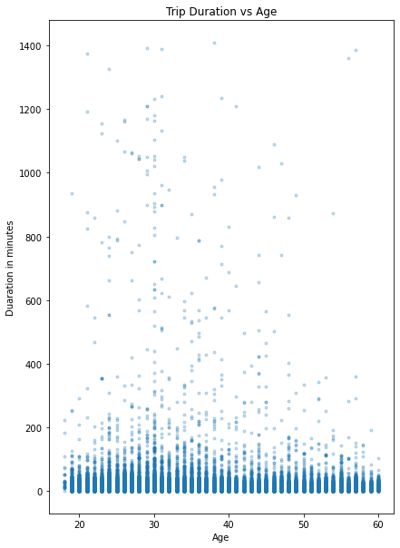

```python
plt.figure(figsize=[15,10])
plt.subplot(1, 2, 1)
plt.scatter((df['member_age']), df['duration_min'], alpha = 0.25, marker = '.' )

plt.title('Trip Duration vs Age')
plt.xlabel('Age')
plt.ylabel('Duaration in minutes')
```

## Trip Duration vs Gender vs Age

in this part I will check the relation between the duration of the trip, the age of the bikers, and the gender of them.

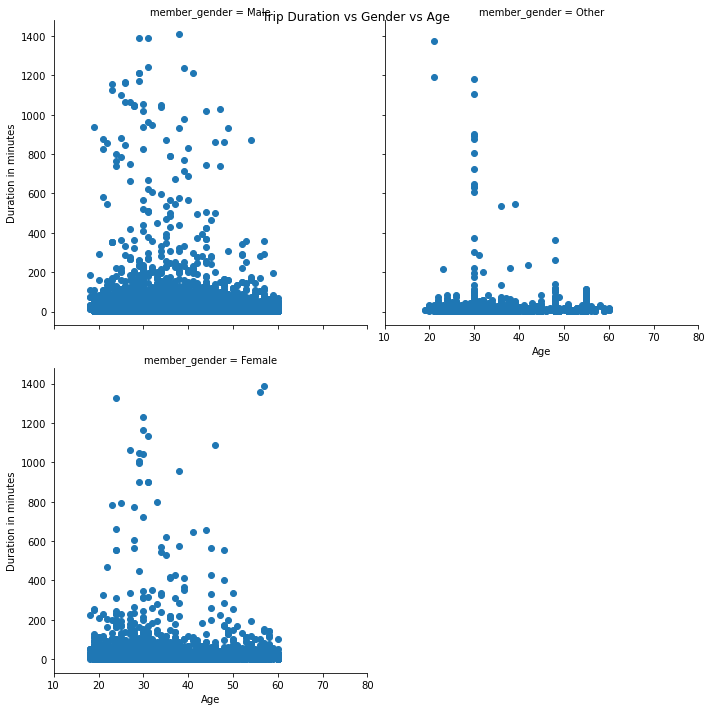

```python
sep_gender = sb.FacetGrid(data = df, col = 'member_gender', col_wrap = 2, size = 5,
                 xlim = [10, 80])
sep_gender.map(plt.scatter, 'member_age', 'duration_min', alpha= 1)


sep_gender.set_xlabels('Age')
sep_gender.set_ylabels('Duration in minutes')
sep_gender.fig.suptitle('Trip Duration vs Gender vs Age')
plt.show();
```